# Geospatial Analytics for Peace

Armed conflict in Myanmar at township level, Jan 2021 – Sep 2025

Murat Kaya

2026-10-25

## Research question

**Where is armed conflict in Myanmar concentrated, and how has it evolved since the 2021 military coup?**

- Myanmar has been in armed conflict since 1948, the world’s longest-running civil war.
- The February 2021 coup sharply escalated the fighting: thousands killed and more than three million people displaced.

**Objectives**

1. Pinpoint the **hot spots, cold spots and spatial outliers** where violence clusters or behaves unusually compared with surrounding townships.
2. Reveal **where, how fast and in what pattern** political violence is evolving over space and time.

The aim is to support peace-building and humanitarian planning.

## Study area and data

| Data | Source |
| --- | --- |
| Conflict events, Jan 2021 – Sep 2025 | ACLED |
| Township boundaries (330 townships) | MIMU v9.4 |

**Data preparation**

- Kept ACLED’s three **political-violence** types: battles, explosions/remote violence and violence against civilians.
- Removed events located only at state/region level and duplicate events.
- Assigned each event to a township with a **spatial join**.
- Counted events and fatalities per township and per **quarter** (19 quarters).

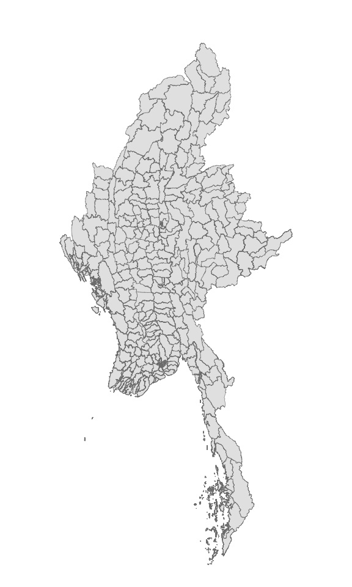

## Analytical approach

| Question | Method |
| --- | --- |
| Is conflict clustered overall? | **Global Moran’s I** (999 permutations) |
| Where are the clusters and outliers? | **Local Moran’s I (LISA)** |
| Where are the hot and cold spots? | **Getis-Ord Gi*** |
| How are hot spots changing over time? | **Mann-Kendall test** and **Emerging Hot Spot Analysis (EHSA)** |
| Do hot spots hold without township boundaries? | **Kernel Density Estimation (KDE)**, value-added analysis |

- **Neighbours:** 8 nearest townships, row-standardised, so island townships also have neighbours.
- **Space-time cube:** 330 townships × 19 quarters.
- Only results with **p < 0.05** are shown on the maps.

## Finding 1: Where violence happens

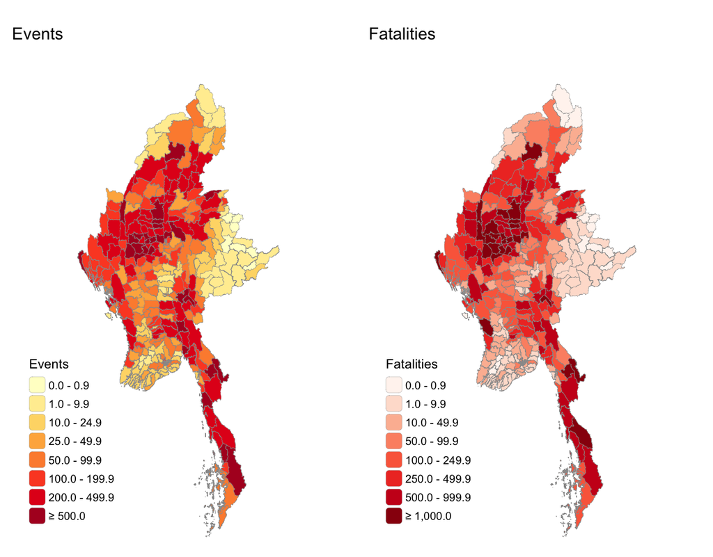

- The **central Dry Zone** (Sagaing, Magway, Mandalay) and the **south-east belt** (Bago East, Kayin, Mon) record the most events and deaths.
- Many townships there have **over 200 events** and **over 1,000 deaths**.
- Eastern Shan and the Ayeyarwady delta remain relatively calm.

## Finding 2: Escalation over time

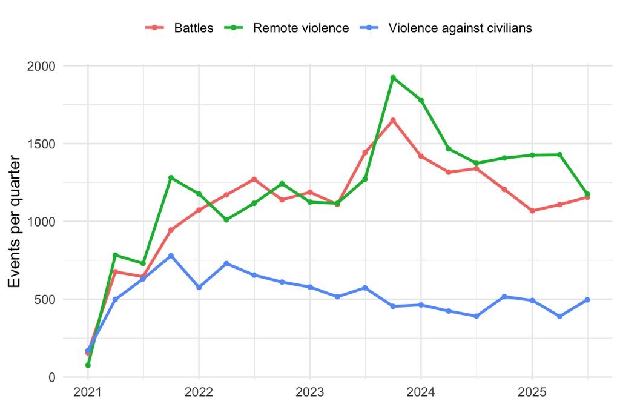

- Events rose from under 200 per type in early 2021 to more than **1,000 per quarter** by 2022.
- Violence **peaked in late 2023** (about 1,900 remote-violence events and 1,650 battles).
- Since 2024, **air strikes, shelling and drones** have outnumbered battles.

## Finding 3: Significant clusters

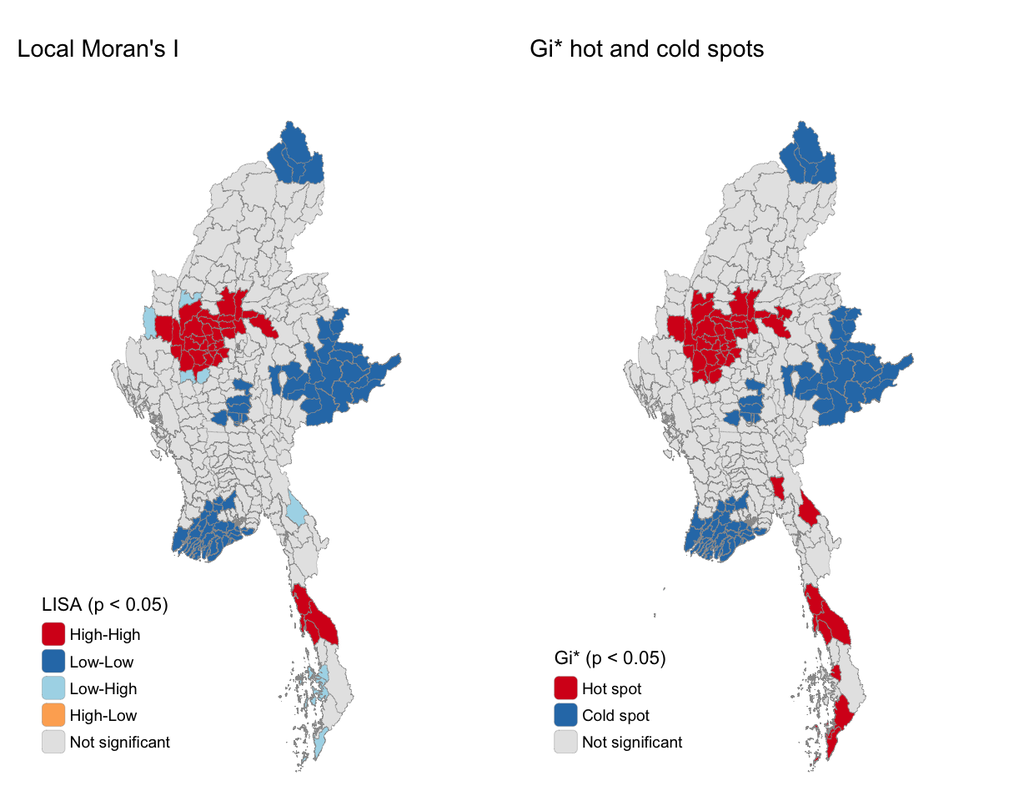

- **Global Moran’s I ≈ 0.40–0.43 (p < 0.001)** for all conflict types: violence is clustered, not random.
- The **central Dry Zone** is the largest High-High cluster and hot spot (31–44 High-High townships, depending on type).
- **Cold spots:** eastern Shan, the Ayeyarwady delta and the far north.

## Finding 4: Shifting hot spots

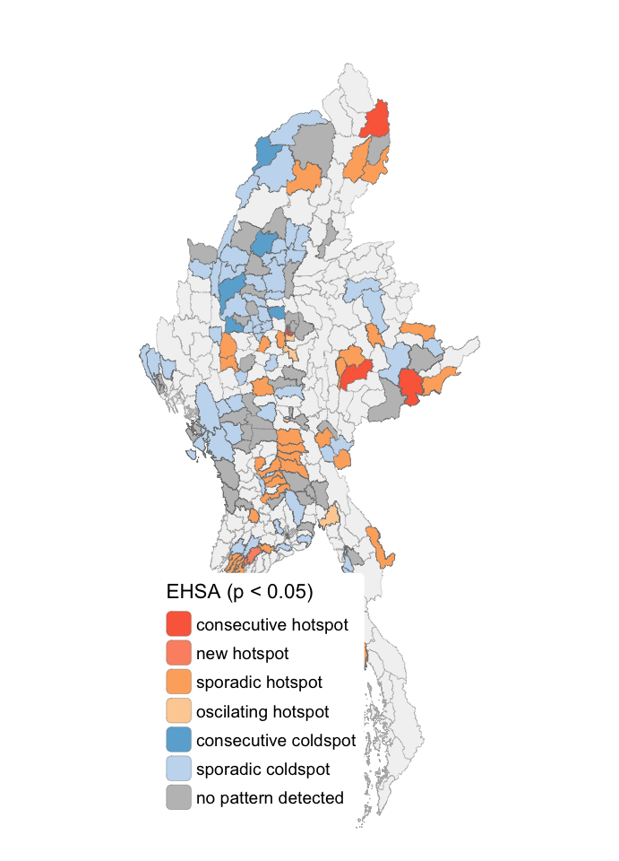

**Mann-Kendall test on quarterly Gi***

| Trend | Townships |
| --- | --- |
| No significant trend | 192 |
| Significant decrease | 88 |
| Significant increase | 50 |

- The strongest increases are in **Bago (West)**, led by Okpho (tau = 0.743), with parts of Magway and Mandalay: conflict is **spreading south from the Dry Zone**.
- Most townships are **sporadic** hot or cold spots: fighting moves from quarter to quarter.
- A few **consecutive hot spots** in Kachin and Shan are emerging areas of concern.

## Finding 5: Hidden urban violence

**Kernel Density Estimation** measures events per km² directly from the points, without township boundaries.

- **14 of the 15** highest-density townships are in **Yangon** (about 120–128 events per 100 km²).
- None is a High-High cluster in the LISA results: Yangon’s townships are so small that each records only a modest count.
- Outside Yangon, the densest township is **Salingyi (Sagaing)**, confirming the Dry Zone hot spot.

Results depend on the choice of spatial unit (the modifiable areal unit problem).

## Limitations

- **Reporting bias:** ACLED depends on media and local reports, so remote areas and places under internet shutdowns may be under-recorded.
- **Location precision:** events known only at state/region level were removed, and many events share the coordinates of the nearest town.
- **Counts, not rates:** population is not taken into account, so large townships may record more events simply because of their size.
- **Fatalities** are conservative ACLED estimates.
- **Method choices:** results depend on the 8-nearest-neighbour weights, township boundaries, the quarterly time step and the 15 km KDE bandwidth.
- **EHSA filtering:** only townships with a significant trend are shown, so stable hot spots such as much of the Dry Zone are under-represented.

## Public-safety implications

- **Central Dry Zone** (Sagaing, Magway, Mandalay): the most consistent hot spot for events and fatalities, and the top priority for humanitarian support and civilian protection.
- **South-east belt** (Bago East, Kayin, Mon): a second major cluster of battles and violence against civilians.
- **Bago (West):** the strongest increasing trends; monitor as conflict spreads south from the Dry Zone.
- **Kachin and Shan:** consecutive and oscillating hot spots can serve as early-warning areas.
- **Yangon:** urban violence is underestimated by township-level analysis and needs separate attention.
- **Cold spots** (eastern Shan, Ayeyarwady delta): potentially safer areas for displaced people and aid operations.